# Hands-On Data Lab Implementation — Titanic Dataset

**Data Science Consultant Internship — Task 2**

This notebook walks through a complete, practical data science workflow on the Titanic dataset: environment setup, data import & exploration, data manipulation, data cleaning, visualization, and statistical analysis with insights.

## 1. Set Up the Data Science Environment

Import Python, Pandas, NumPy, and the visualization libraries Matplotlib and Seaborn, and configure default plot styling.

```python
import pandas as pd
import numpy as np
import matplotlib.pyplot as plt
import seaborn as sns

# Display settings
pd.set_option('display.max_columns', None)
sns.set_style('whitegrid')
plt.rcParams['figure.figsize'] = (8, 5)

print("Environment ready")
print("Pandas:", pd.__version__)
print("NumPy:", np.__version__)
print("Seaborn:", sns.__version__)
```

```
Environment ready
Pandas: 3.0.3
NumPy: 2.4.6
Seaborn: 0.13.2
```

## 2. Import & Explore the Data

Load the Titanic dataset directly from Seaborn's built-in dataset repository (no manual download needed), then examine its structure, column data types, and summary statistics.

```python
# Load the Titanic dataset (built into Seaborn)
df = sns.load_dataset('titanic')

# Basic structure
print("Shape (rows, columns):", df.shape)
df.head()
```

```
Shape (rows, columns): (891, 15)
```

|  | survived | pclass | sex | age | sibsp | parch | fare | embarked | class | who | adult_male | deck | embark_town | alive | alone |
| --- | --- | --- | --- | --- | --- | --- | --- | --- | --- | --- | --- | --- | --- | --- | --- |
| 0 | 0 | 3 | male | 22.0 | 1 | 0 | 7.2500 | S | Third | man | True | NaN | Southampton | no | False |
| 1 | 1 | 1 | female | 38.0 | 1 | 0 | 71.2833 | C | First | woman | False | C | Cherbourg | yes | False |
| 2 | 1 | 3 | female | 26.0 | 0 | 0 | 7.9250 | S | Third | woman | False | NaN | Southampton | yes | True |
| 3 | 1 | 1 | female | 35.0 | 1 | 0 | 53.1000 | S | First | woman | False | C | Southampton | yes | False |
| 4 | 0 | 3 | male | 35.0 | 0 | 0 | 8.0500 | S | Third | man | True | NaN | Southampton | no | True |

```python
# Column data types and non-null counts
df.info()
```

```
<class 'pandas.DataFrame'>
RangeIndex: 891 entries, 0 to 890
Data columns (total 15 columns):
 #   Column       Non-Null Count  Dtype
---  ------       --------------  -----
 0   survived     891 non-null    int64
 1   pclass       891 non-null    int64
 2   sex          891 non-null    str
 3   age          714 non-null    float64
 4   sibsp        891 non-null    int64
 5   parch        891 non-null    int64
 6   fare         891 non-null    float64
 7   embarked     889 non-null    str
 8   class        891 non-null    category
 9   who          891 non-null    str
 10  adult_male   891 non-null    bool
 11  deck         203 non-null    category
 12  embark_town  889 non-null    str
 13  alive        891 non-null    str
 14  alone        891 non-null    bool
dtypes: bool(2), category(2), float64(2), int64(4), str(5)
memory usage: 100.4 KB
```

```python
# Descriptive statistics for numeric columns
df.describe()
```

|  | survived | pclass | age | sibsp | parch | fare |
| --- | --- | --- | --- | --- | --- | --- |
| count | 891.000000 | 891.000000 | 714.000000 | 891.000000 | 891.000000 | 891.000000 |
| mean | 0.383838 | 2.308642 | 29.699118 | 0.523008 | 0.381594 | 32.204208 |
| std | 0.486592 | 0.836071 | 14.526497 | 1.102743 | 0.806057 | 49.693429 |
| min | 0.000000 | 1.000000 | 0.420000 | 0.000000 | 0.000000 | 0.000000 |
| 25% | 0.000000 | 2.000000 | 20.125000 | 0.000000 | 0.000000 | 7.910400 |
| 50% | 0.000000 | 3.000000 | 28.000000 | 0.000000 | 0.000000 | 14.454200 |
| 75% | 1.000000 | 3.000000 | 38.000000 | 1.000000 | 0.000000 | 31.000000 |
| max | 1.000000 | 3.000000 | 80.000000 | 8.000000 | 6.000000 | 512.329200 |

```python
# Check missing values in every column
df.isnull().sum().sort_values(ascending=False)
```

```
deck           688
age            177
embarked         2
embark_town      2
sex              0
pclass           0
survived         0
fare             0
parch            0
sibsp            0
class            0
adult_male       0
who              0
alive            0
alone            0
dtype: int64
```

**Observations:**

- The dataset has 891 passenger records with 15 columns covering demographics (age, sex), travel class, fare, embarkation port, and the survival outcome.
- `deck` has the most missing values, followed by `age` and `embark_town`/`embarked`.
- `survived` (0/1) is the target variable for any downstream classification task.

## 3. Data Manipulation

Practice filtering, sorting, grouping, merging-style transformations, and creating new columns from existing ones using Pandas.

```python
# Filtering: female passengers travelling in 1st class
first_class_women = df[(df['sex'] == 'female') & (df['pclass'] == 1)]
print("First-class women passengers:", len(first_class_women))
first_class_women[['sex', 'pclass', 'age', 'fare', 'survived']].head()
```

```
First-class women passengers: 94
```

|  | sex | pclass | age | fare | survived |
| --- | --- | --- | --- | --- | --- |
| 1 | female | 1 | 38.0 | 71.2833 | 1 |
| 3 | female | 1 | 35.0 | 53.1000 | 1 |
| 11 | female | 1 | 58.0 | 26.5500 | 1 |
| 31 | female | 1 | NaN | 146.5208 | 1 |
| 52 | female | 1 | 49.0 | 76.7292 | 1 |

```python
# Sorting: passengers sorted by fare paid, highest first
df.sort_values(by='fare', ascending=False)[['sex', 'pclass', 'fare', 'survived']].head(10)
```

|  | sex | pclass | fare | survived |
| --- | --- | --- | --- | --- |
| 679 | male | 1 | 512.3292 | 1 |
| 258 | female | 1 | 512.3292 | 1 |
| 737 | male | 1 | 512.3292 | 1 |
| 88 | female | 1 | 263.0000 | 1 |
| 438 | male | 1 | 263.0000 | 0 |
| 341 | female | 1 | 263.0000 | 1 |
| 27 | male | 1 | 263.0000 | 0 |
| 742 | female | 1 | 262.3750 | 1 |
| 311 | female | 1 | 262.3750 | 1 |
| 299 | female | 1 | 247.5208 | 1 |

```python
# Grouping: survival rate by passenger class and gender
survival_by_class_gender = df.groupby(['pclass', 'sex'])['survived'].mean().round(3)
survival_by_class_gender
```

```
pclass  sex
1       female    0.968
        male      0.369
2       female    0.921
        male      0.157
3       female    0.500
        male      0.135
Name: survived, dtype: float64
```

```python
# Grouping: average fare and age by embarkation town
df.groupby('embark_town')[['fare', 'age']].mean().round(2)
```

| embark_town | fare | age |
| --- | --- | --- |
| Cherbourg | 59.95 | 30.81 |
| Queenstown | 13.28 | 28.09 |
| Southampton | 27.08 | 29.45 |

```python
# Column transformation: create an 'age_group' column from 'age'
bins = [0, 12, 18, 35, 60, 100]
labels = ['Child', 'Teen', 'Young Adult', 'Adult', 'Senior']
df['age_group'] = pd.cut(df['age'], bins=bins, labels=labels)

# Column transformation: family size from sibsp + parch
df['family_size'] = df['sibsp'] + df['parch'] + 1

df[['age', 'age_group', 'sibsp', 'parch', 'family_size']].head()
```

|  | age | age_group | sibsp | parch | family_size |
| --- | --- | --- | --- | --- | --- |
| 0 | 22.0 | Young Adult | 1 | 0 | 2 |
| 1 | 38.0 | Adult | 1 | 0 | 2 |
| 2 | 26.0 | Young Adult | 0 | 0 | 1 |
| 3 | 35.0 | Young Adult | 1 | 0 | 2 |
| 4 | 35.0 | Young Adult | 0 | 0 | 1 |

## 4. Data Cleaning

Handle missing values, duplicate records, and incorrect data types to prepare the dataset for reliable analysis.

```python
# Impute missing 'age' values with the median age
median_age = df['age'].median()
df['age'] = df['age'].fillna(median_age)
print(f"Missing age values filled with median: {median_age}")
```

```
Missing age values filled with median: 28.0
```

```python
# 'deck' has too many missing values to impute meaningfully — drop it
df = df.drop(columns=['deck'])

# Fill the few missing 'embarked'/'embark_town' values with the most frequent port (mode)
df['embarked'] = df['embarked'].fillna(df['embarked'].mode()[0])
df['embark_town'] = df['embark_town'].fillna(df['embark_town'].mode()[0])

print("Remaining missing values:")
print(df.isnull().sum()[df.isnull().sum() > 0])
```

```
Remaining missing values:
age_group    177
dtype: int64
```

```python
# Check for and remove duplicate rows
duplicate_count = df.duplicated().sum()
print("Duplicate rows found:", duplicate_count)
df = df.drop_duplicates()
print("Shape after removing duplicates:", df.shape)
```

```
Duplicate rows found: 111
Shape after removing duplicates: (780, 16)
```

```python
# Correct data types: convert categorical text columns to category dtype for efficiency
cat_cols = ['sex', 'embarked', 'embark_town', 'class', 'who', 'alive']
for col in cat_cols:
    df[col] = df[col].astype('category')

df.dtypes
```

```
survived          int64
pclass            int64
sex            category
age             float64
sibsp             int64
parch             int64
fare            float64
embarked       category
class          category
who            category
adult_male         bool
embark_town    category
alive          category
alone              bool
age_group      category
family_size       int64
dtype: object
```

## 5. Data Visualization

Create Seaborn/Matplotlib charts to visualize survival patterns, distributions, and correlations.

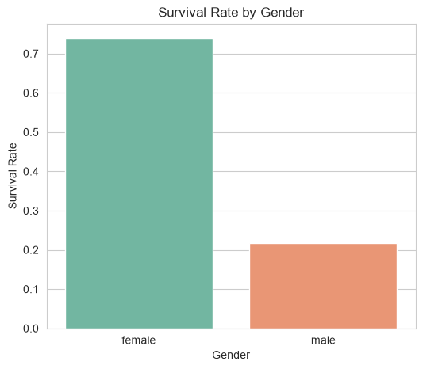

```python
# Bar chart: survival rate by gender
plt.figure(figsize=(6, 5))
sns.barplot(data=df, x='sex', y='survived', palette='Set2', errorbar=None)
plt.title('Survival Rate by Gender')
plt.ylabel('Survival Rate')
plt.xlabel('Gender')
plt.show()
```

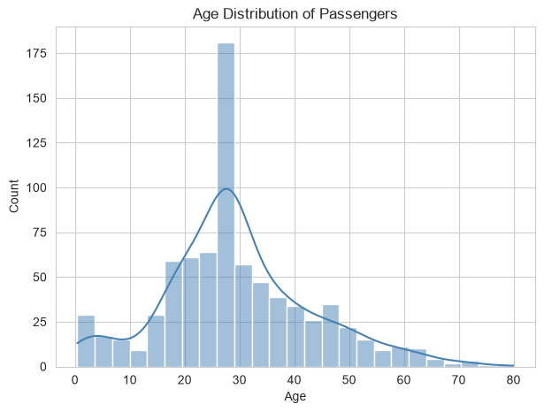

```python
# Histogram: age distribution
plt.figure(figsize=(7, 5))
sns.histplot(df['age'], bins=25, kde=True, color='steelblue')
plt.title('Age Distribution of Passengers')
plt.xlabel('Age')
plt.ylabel('Count')
plt.show()
```

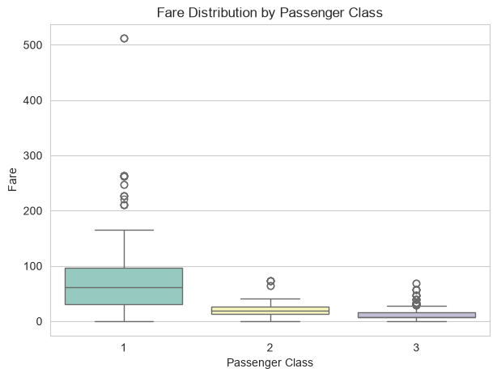

```python
# Box plot: fare distribution by passenger class
plt.figure(figsize=(7, 5))
sns.boxplot(data=df, x='pclass', y='fare', palette='Set3')
plt.title('Fare Distribution by Passenger Class')
plt.xlabel('Passenger Class')
plt.ylabel('Fare')
plt.show()
```

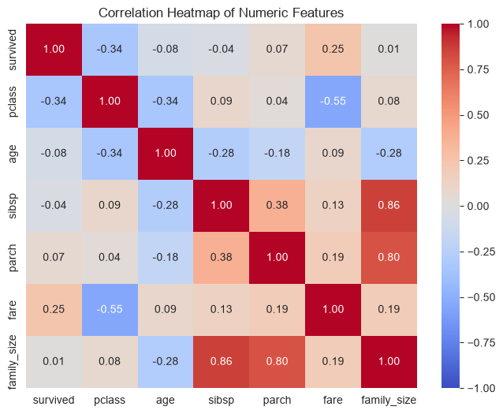

```python
# Heatmap: correlation between numeric features
plt.figure(figsize=(8, 6))
numeric_df = df.select_dtypes(include=[np.number])
corr = numeric_df.corr()
sns.heatmap(corr, annot=True, cmap='coolwarm', fmt='.2f', vmin=-1, vmax=1)
plt.title('Correlation Heatmap of Numeric Features')
plt.show()
```

## 6. Basic Data Analysis & Insights

Summary statistics and key takeaways from the analysis above.

```python
# Key summary statistics
overall_survival_rate = df['survived'].mean()
print(f"Overall survival rate: {overall_survival_rate:.2%}")

print("\nSurvival rate by class:")
print(df.groupby('pclass')['survived'].mean().round(3))

print("\nSurvival rate by gender:")
print(df.groupby('sex')['survived'].mean().round(3))

print("\nAverage fare by class:")
print(df.groupby('pclass')['fare'].mean().round(2))
```

```
Overall survival rate: 41.28%

Survival rate by class:
pclass
1    0.637
2    0.506
3    0.257
Name: survived, dtype: float64

Survival rate by gender:
sex
female    0.740
male      0.217
Name: survived, dtype: float64

Average fare by class:
pclass
1    85.16
2    21.89
3    13.67
Name: fare, dtype: float64
```

**Conclusion:** Socio-economic status (class/fare) and gender were the two dominant factors influencing survival aboard the Titanic, consistent with historical accounts of the evacuation priorities.